# Trouver rapidement des solutions à la pandémie de coronavirus

19.04.2022

**Le FNS soutient la recherche en lien avec le coronavirus. Avec succès: les résultats sont rapides et utiles.**

La pandémie de coronavirus qui nous touche depuis le début de l’année 2020 a mis en évidence l’importance de la recherche scientifique. Ce virus inconnu jusqu’alors devait être rapidement décrypté pour, entre autres, pouvoir développer des médicaments et vaccins efficaces et déterminer quelles mesures de prévention s’imposaient. Le FNS a participé à cet effort en finançant de nombreux projets de recherche. Aperçu.

### Un virus à appréhender

Au total, 107 projets en lien avec le coronavirus ont été financés ou sont encore financés par le FNS pour un montant de 45 millions de francs.

La variété des projets en lien avec le coronavirus est bien illustrée par un nuage de mots. Celui-ci reflète la fréquence des mots-clés utilisés dans les différents projets en lien avec le coronavirus. Il montre bien que ce qui préoccupe les scientifiques est d’abord de mieux comprendre ce virus et ses risques sanitaires.

Wordcloud de projets liés au covid

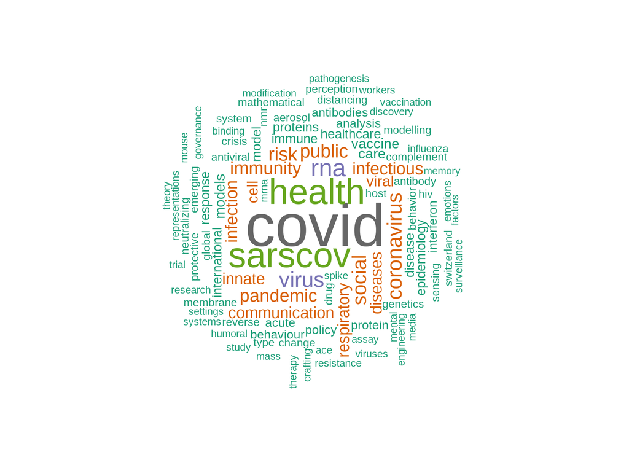

### Plusieurs formes de soutien

Les projets ont été soutenus par différents instruments: un appel spécial à projets «coronavirus» a permis de financer 45 projets à partir de l’été 2020 tandis que le [Programme national de recherche «Covid-19» (PNR 78)](https://www.nfp78.ch/en/), sur mandat du Conseil fédéral, en a soutenu 28. Dans le cadre de l’encouragement classique de projets, les scientifiques ont aussi soumis des requêtes en lien de près ou de loin avec le coronavirus – que ce soit avant la pandémie de SARS-CoV-2 ou depuis. 34 projets sont concernés. 184 scientifiques sont engagés dans les projets concernés.

Nombre et pourcentage de subsides liés au Covid (sur un total de 107) dans chaque groupe défini par la mise au concours

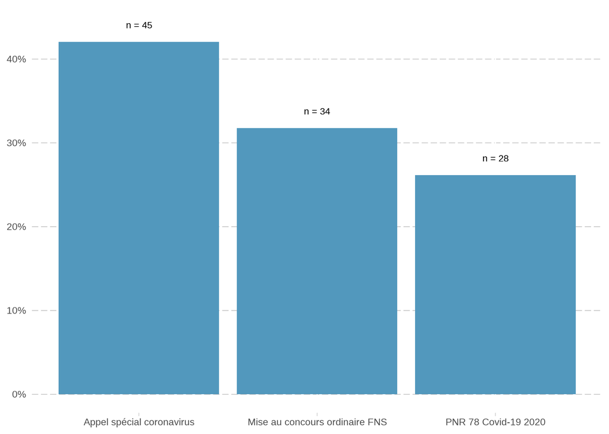

### Des résultats utiles

La durée moyenne des projets relatifs au coronavirus est de deux ans. Certains projets ont déjà livré des résultats et abouti à des publications qui ont permis de progresser dans la lutte contre la pandémie: 87 publications dans le domaine sciences de la vie, et 32 publications dans les sciences humaines et sociales. Ce nombre est amené à augmenter puisque 69 % des projets sont encore en cours.

Deux exemples:

- L’équipe de Volker Thiel, virologue à l’Université de Berne et à l’Institut de virologie et d’immunologie IVI, montre dans sa publication que son vaccin vivant atténué sous forme de spray nasal est prometteur. Son développement se poursuit avec le passage aux études cliniques.
- Un [article](https://www.manchesteropenhive.com/view/journals/hrv/7/2/article-p41.xml) - dont le chercheur Marc-Antoine Berthod est l’un des auteurs - qui s’intéresse aux pratiques funéraires met en évidence les changements que la pandémie a occasionnés.

Le FNS a aussi communiqué sur certains résultats. Il a notamment informé sur:

- Un [modèle statistique](https://www.snf.ch/fr/BZARkjTMtrt48Gcb/news/coronavirus-limpact-des-fermetures-de-frontieres-et-decoles) qui a permis de mesurer l’impact des fermetures de frontières et d’écoles
- La création d’un [modèle non contagieux du SARS-CoV-2](https://www.snf.ch/fr/IR4xqilNfvUoe4E7/news/un-modele-du-sars-cov-2-ameliore-la-recherche-et-le-developpement-de-medicaments) pour améliorer la recherche et le développement de médicaments
- Une [étude de cohorte](https://www.snf.ch/fr/6AywkKU0LqBlQ92j/news/des-precisions-sur-le-covid-long) (3000 personnes) qui a mis en évidence l’existence d’une corrélation entre la gravité de l’infection et l’apparition de symptômes du Covid long
- Une méthode pour estimer rapidement et à moindre coût le [taux de reproduction](https://www.snf.ch/fr/Mhz1a3piOEoSgb2B/news/le-taux-de-reproduction-du-coronavirus-se-lit-dans-les-eaux-usees) du coronavirus à partir des eaux usées
- Des [candidats vaccins suisses](https://www.nfp78.ch/fr/news/des-candidats-vaccins-suisses-entament-la-phase-d-etudes-cliniques/), développés dans le cadres du PNR 78, entament la phase d’études cliniques ([voir aussi](https://www.snf.ch/fr/XZ6J2kZHkf5aMROA/news/recherche-novatrice-sur-de-nouveaux-vaccins))

### Les sciences de la vie en tête de classement

Une analyse plus détaillée des projets soutenus fait apparaître que presque deux tiers d’entre eux relèvent des sciences de la vie, presque un tiers des disciplines des sciences humaines et sociales et seulement un petit nombre des mathématiques, sciences naturelles et de l’ingénieur. Une répartition qui représente la nature du défi que pose la pandémie et qui contraste avec l’ensemble des projets financés par le FNS, qui sont plutôt équitablement répartis entre les disciplines.

Cette donne est toutefois amenée à changer puisqu’un nouveau Programme national de recherche [«Covid-19 et société»](https://www.nfp80.ch/en/) (PNR 80) démarre en 2021. Ce PNR s’adresse principalement aux sciences humaines et sociales. Les projets seront sélectionnés au cours de l’été 2022.

Nombre et pourcentage de subsides liés au Covid-19 (sur un total de 107) par domaine de recherche

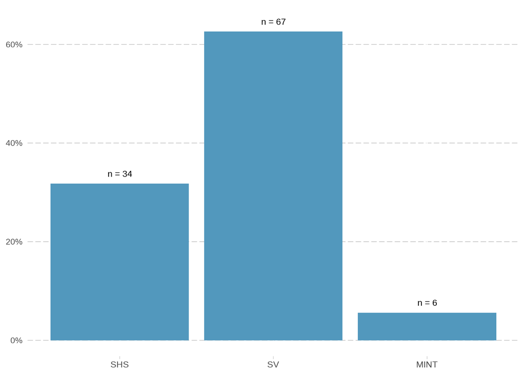

Total des fonds dépensés (en francs suisses) sur 107 projets liés au covid pour chaque domaine de recherche.

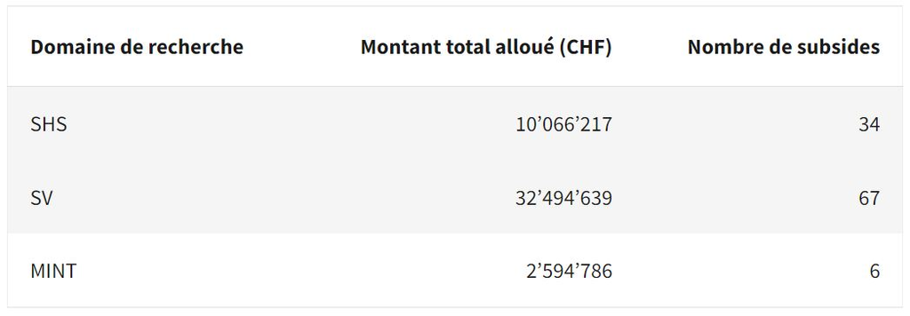

| Domaine de recherche | Montant total alloué (CHF) | Nombre de subsides |
| --- | --- | --- |
| SHS | 10’066’217 | 34 |
| SV | 32’494’639 | 67 |
| MINT | 2’594’786 | 6 |

L’illustration suivante présente le nombre et le pourcentage de projets liés au coronavirus dans chaque discipline. On observe à nouveau la prédominance de certaines disciplines. La médecine préventive est sans surprise en tête de classement. La recherche fondamentale en biologie suit: de nombreux projets cherchent en effet à comprendre le virus. Mais on note aussi que quelques projets en sciences humaines et sociales s’intéressent aux réactions de la société face à la pandémie et aux conséquences de cette dernière.

Nombre et pourcentage de subsides liés au Covid (sur un total de 107) par domaine de recherche

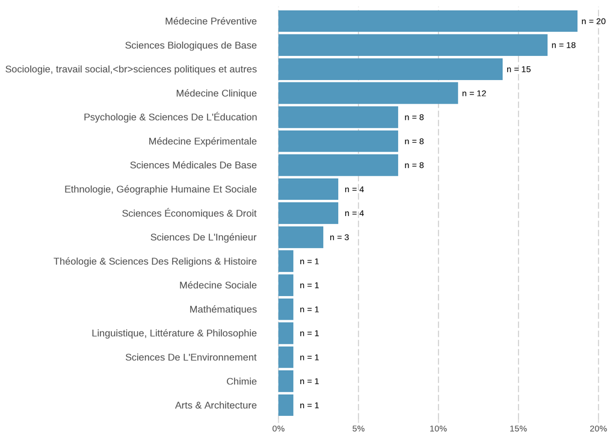

### La recherche fondamentale nécessite d’importants fonds

La recherche fondamentale est onéreuse: le tableau montre que la discipline qui a reçu le plus d’argent – 10.7 millions de francs – est la recherche fondamentale en biologie.

Montant total (en francs suisses) accordés à des projets dans les sept disciplines les plus fréquentes.

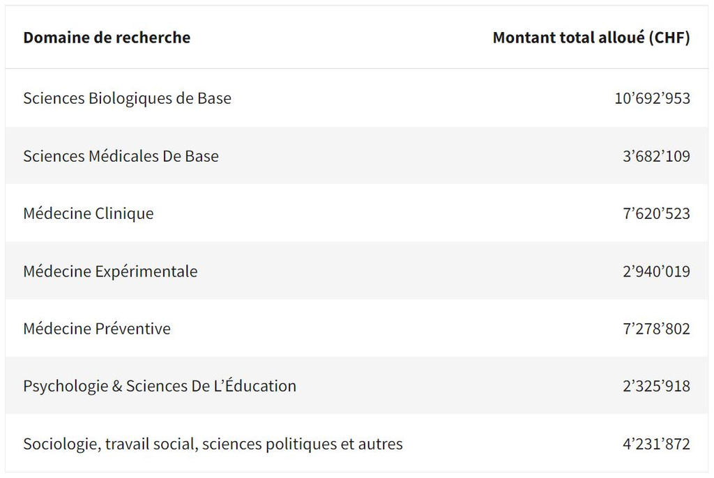

| Domaine de recherche | Montant total alloué (CHF) |
| --- | --- |
| Sciences Biologiques de Base | 10’692’953 |
| Sciences Médicales De Base | 3’682’109 |
| Médecine Clinique | 7’620’523 |
| Médecine Expérimentale | 2’940’019 |
| Médecine Préventive | 7’278’802 |
| Psychologie & Sciences De L’Éducation | 2’325’918 |
| Sociologie, travail social, sciences politiques et autres | 4’231’872 |

### Registre des projets Covid-19

Tous les projets de recherche en lien avec le coronavirus sont rassemblés dans [un registre](https://data.snf.ch/covid-19). Ce registre des projets offre un aperçu de la recherche sur le Covid-19 en Suisse financée par le FNS, par Innosuisse et par le programme-cadre européen pour la recherche Horizon 2020.

Les données, le texte et le code de ce récit de données sont disponibles sur [Github](https://github.com/snsf-data/datastory_covid_19_funding) et archivés sur [Zenodo](https://doi.org/10.46446/datastory.covid-19-funding) . DOI: 10.46446/datastory.covid-19-funding